# Exponential Distribution Simulation

mickfenneck

# Introduction

The project is meant to answer to this particular question:

> The exponential distribution can be simulated in R with rexp(n, lambda) where lambda is the rate parameter. The mean of exponential distribution is 1/lambda and the standard deviation is also also 1/lambda. Set lambda = 0.2 for all of the simulations. In this simulation, you will investigate the distribution of averages of 40 exponential(0.2)s. Note that you will need to do a thousand or so simulated averages of 40 exponentials.

> Illustrate via simulation and associated explanatory text the properties of the distribution of the mean of 40 exponential(0.2)s. You should:
> 1. Show where the distribution is centered at and compare it to the theoretical center of the distribution.
> 2. Show how variable it is and compare it to the theoretical variance of the distribution.
> 3. Show that the distribution is approximately normal.
> 4. Evaluate the coverage of the confidence interval for 1/lambda:: $\bar X \pm 1.96 \frac{S}{\sqrt{n}}$.

# The Solution

### Generating the Data

In order to start simulating the distribution I set the seed so everybody should reproduce in the same way this experiment. The text says to set the number of tests equal to 1000 and lambda equal to 0.2

```r
set.seed(1994)
lambda <- 0.2
numTests <- 1000
testCount <- 40
data <- matrix(rexp(numTests * testCount, rate=lambda), nrow = numTests)
means <- rowMeans(data)

# Compute the mean of each row of the generated data.
meanDist <- apply(data, 1, mean)
```

We can now concetrate on some particular values:

```r
centre <- round(mean(meanDist), 3)
theoreticalmean <- round(1/lambda, 3)

SD <- round(sd(meanDist), 3)
theoreticalSD <- round(1/(lambda * sqrt(testCount)), 3)

var <- round(var(meanDist), 3)
theoreticalvar <- round((1/(lambda * sqrt(testCount)))^2, 3)
```

After the computation of the values we can quickly compare them:

```
-   mean: |centre-theoreticalmean| = 0.012
-   standar deviation: |SD-theoreticalSD| = 0.011
-   variance: |var-theoreticalvar| = 0.017
```

As we can see, the values are not only comparable but almost the same. We can quickly provide a graphical rappresentation by plotting the data.

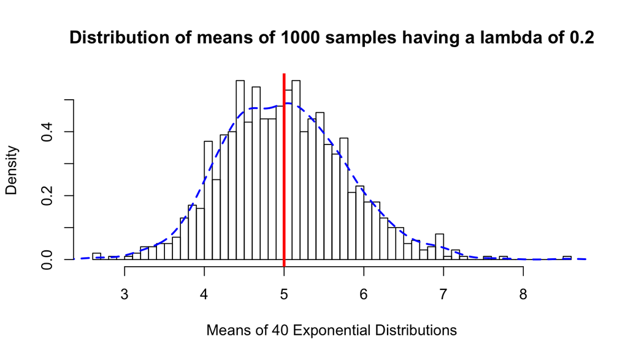

```r
# plot the histogram of the means
hist(means, breaks=50, prob=TRUE,
     main="Distribution of means of 1000 samples having a lambda of 0.2",
     xlab="Means of 40 Exponential Distributions",
     ylab="Density")
lines(density(means), col="blue", lwd=2, lty=2)
# show the mean of distribution
abline(v=1/lambda, col="red", lwd=3)
```

The plot shows that the distribution get close to the normal distribution.

Using a QQplot we can show that the distribution is very similar to the normal, apart from the tails that tends to diverge from the line.

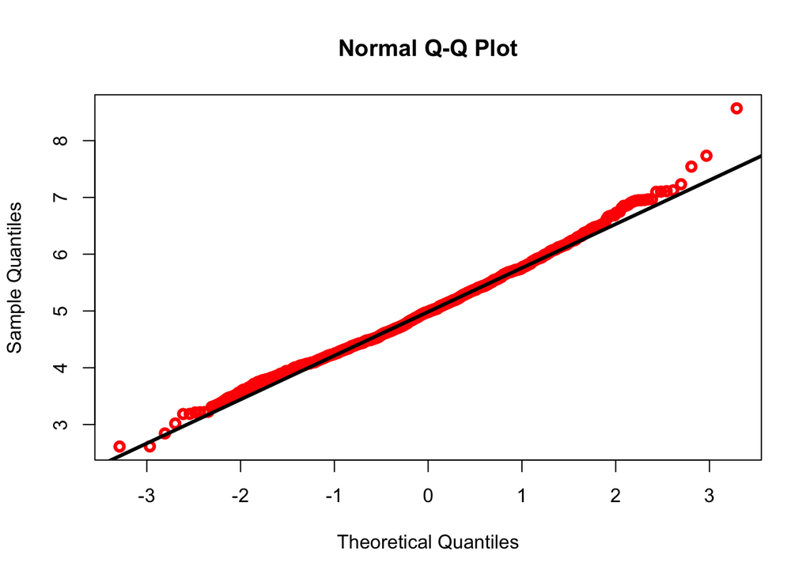

```r
qqnorm(means, col="red", lwd=3)
qqline(means, col="black", lwd=3)
```

### Final consideration

We can finally compute the 95% confidence intervals:

```r
CI <- 1.96
ll <- mean(means) - CI * (sd(means)/sqrt(testCount))
ul <- mean(means) + CI * (sd(means)/sqrt(testCount))
```

Lower interval `4.77` and upper interval `5.253`.

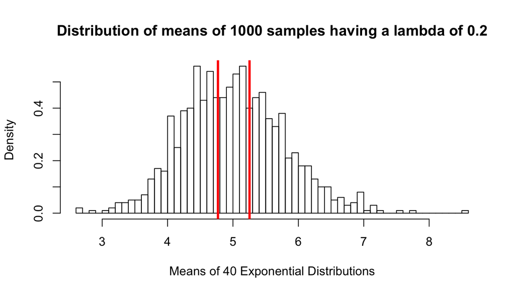

```r
# plot the histogram of the means
hist(means, breaks=50, prob=TRUE,
     main="Distribution of means of 1000 samples having a lambda of 0.2",
     xlab="Means of 40 Exponential Distributions",
     ylab="Density")
# show the two CIs
abline(v=c(ll, ul), col="red", lwd=3)
```

## Code Reproducibility

You can reproduce the code how many times you want. The R source is available on github.com at https://github.com/mickfenneck/statinference.